# Análisis del impacto de la tasa de interés con modelos predictivos

La motivación de este proyecto surge a raíz del inminente cambio de gobierno en Estados Unidos, donde se ha comenzado a discutir la implementación de nuevas tasas de importación y cómo estas podrían afectar los precios dentro del país. Ante las diversas opiniones sobre este impacto, se ha puesto el foco en el papel de la Reserva Federal (FED) y su influencia no solo en la economía estadounidense, sino también en la de otros países. A partir de este debate, el proyecto busca entender la relación entre la tasa de interés de la FED y la inflación mediante el análisis de datos históricos y la evaluación del rendimiento de modelos predictivos.

## Librerías

Importamos las librerías a utilizar.

```r
# Análisis financiero
library(quantmod)
# Series temporales
library(tseries)
# Transformación de datos
library(dplyr)
library(tidyr)
library(reshape2)
library(kableExtra)
library(purrr)

# Modelado de datos
library(lmtest)
library(randomForest)
library(caret)
# Gráficos
library(ggplot2)
```

## 1 Carga de datos

Obtenemos los datos a trabajar, por un lado el registro histórico de la tasa de interés de la FED y por el otro el índice del precios al consumidor o inflación. Creamos un Data Frame para cada uno. Los datos son provistos por la [FRED](https://fred.stlouisfed.org/). Tomamos como inicio 1990.

```r
first_date <- "1990-01-01"

# Obtener los datos de la tasa de interés de la FED y de la inflación (IPC)
getSymbols("FEDFUNDS", src = "FRED", from = first_date, to = Sys.Date())
```

```
[1] "FEDFUNDS"
```

```r
getSymbols("CPIAUCNS", src = "FRED", from = first_date, to = Sys.Date())
```

```
[1] "CPIAUCNS"
```

```r
# Convertir a Data Frame y renombrar la columna
fed_df <- data.frame(
  Date = index(FEDFUNDS),
  FED = as.numeric(FEDFUNDS[, 1])
)

ipc_df <- data.frame(
  Date = index(CPIAUCNS),
  IPC = as.numeric(CPIAUCNS[, 1])
)
```

La inflación viene dada como suma acumulada, pero lo que nos interesa es el valor mensual, por lo que creamos una nueva columna que exprese esa diferencia.

```r
# Calcular el incremento mensual del IPC
ipc_df$IPC_Monthly <- c(NA, diff(ipc_df$IPC))
```

Graficamos la evolución en el tiempo de los parámetros a analizar.

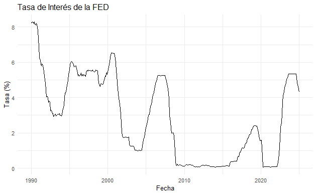

```r
# Graficar tasa de interés de la FED
ggplot(fed_df, aes(x = Date, y = FED)) +
  geom_line() +
  ggtitle("Tasa de Interés de la FED") +
  xlab("Fecha") +
  ylab("Tasa (%)") +
  theme_minimal()
```

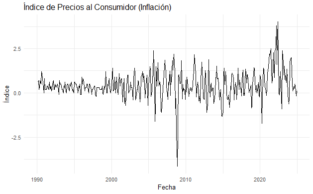

```r
# Graficar inflación (IPC)
ggplot(ipc_df, aes(x = Date, y = IPC_Monthly)) +
  geom_line() +
  ggtitle("Índice de Precios al Consumidor (Inflación)") +
  xlab("Fecha") +
  ylab("Índice") +
  theme_minimal()
```

## 2 Relación entre FED & IPC

### 2.1 Correlación

Analizamos la correlación entre la tasa de la FED y el IPC.

```r
# Correlación entre la tasa de la FED y la inflación mes a mes
merged_df <- merge(fed_df, ipc_df, by = "Date")
correlacion <- cor(merged_df$FED, merged_df$IPC_Monthly, use = "complete.obs")
print(correlacion)
```

```
[1] -0.008073836
```

El valor cercano a cero indica que no hay una correlación entre los datos. Teniendo en cuenta que la relación puede no darse en cada mes sino extendiéndose en el tiempo, vemos qué pasa tomando los valores año a año.

```r
# Correlación entre la tasa de la FED y la inflación año a año

# Promedio anual de la FED
fed_df$Year <- format(fed_df$Date, "%Y")
fed_annual <- aggregate(FED ~ Year, data = fed_df, FUN = mean)

# Promedio anual del IPC
ipc_df$Year <- format(ipc_df$Date, "%Y")
ipc_annual <- aggregate(IPC ~ Year, data = ipc_df, FUN = mean)
ipc_annual$IPC_Annualy <- c(NA, diff(ipc_annual$IPC))

merged_annual <- merge(fed_annual, ipc_annual, by = "Year")
merged_annual <- na.omit(merged_annual)
correlacio_annual <- cor(merged_annual$FED, merged_annual$IPC_Annualy, use = "complete.obs")
print(correlacio_annual)
```

```
[1] 0.08073739
```

El valor es muy similar y cercano a cero, por lo que no encontramos una correlación entre los datos. Vemos reflejados estos resultados en el gráfico de las dos variables juntas.

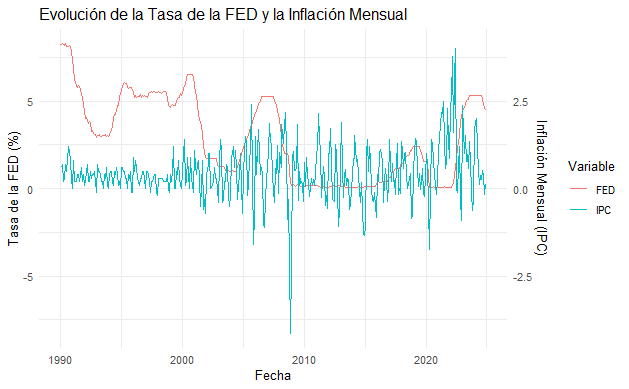

```r
ggplot(merged_df, aes(x = Date)) +
  geom_line(aes(y = FED, color = "FED")) +
  geom_line(aes(y = IPC_Monthly * 2, color = "IPC")) +
  scale_y_continuous(
    name = "Tasa de la FED (%)",
    sec.axis = sec_axis(~ . / 2, name = "Inflación Mensual (IPC)")
  ) +
  labs(
    title = "Evolución de la Tasa de la FED y la Inflación Mensual",
    x = "Fecha",
    color = "Variable"
  ) +
  theme_minimal()
```

### 2.2 Test de causalidad de Granger

El Test de Granger evalúa si una serie temporal X ayuda a predecir otra serie temporal Y. Se basa en la idea de que, si conocer valores pasados de X mejora la predicción de Y, entonces se dice que X causa a Y en el sentido de Granger.

Para esto creamos dos series temporales, una para la FED y otra para el IPC, que se usan para analizar el impacto de los meses anteriores en la variable actual.

```r
# Series temporaleS
merged_df <- na.omit(merged_df)
fed_ts <- ts(merged_df$FED, start = c(2000, 1), frequency = 12)
ipc_ts <- ts(merged_df$IPC_Monthly, start = c(2000, 1), frequency = 12)

# Lags a utilizar: 12 meses
granger_test <- grangertest(ipc_ts ~ fed_ts, order = 12) # FED -> IPC
print(granger_test)
```

```
Granger causality test

Model 1: ipc_ts ~ Lags(ipc_ts, 1:12) + Lags(fed_ts, 1:12)
Model 2: ipc_ts ~ Lags(ipc_ts, 1:12)
  Res.Df  Df     F  Pr(>F)
1    382
2    394 -12 2.115 0.01535 *
---
Signif. codes:  0 ‘***’ 0.001 ‘**’ 0.01 ‘*’ 0.05 ‘.’ 0.1 ‘ ’ 1
```

#### Prueba FED → IPC

El test compara dos modelos de regresión:

- **Modelo 1**:
  $$IPC_t = \alpha + \sum_{i=1}^{12} \beta_i IPC_{t-i} + \sum_{i=1}^{12}
  \gamma_i FED_{t-i} + \varepsilon_t$$
  Este modelo usa los valores pasados de IPC y FED para predecir el IPC actual.
- **Modelo 2**:
  $$IPC_t = \alpha + \sum_{i=1}^{12} \beta_i IPC_{t-i} + \varepsilon_t$$
  Este modelo usa solo los valores pasados de IPC, sin considerar la FED.

#### Interpretación

| **Columna** | **Significado** |
| --- | --- |
| **Res.Df** | Grados de libertad después del ajuste del modelo |
| **Df** | Diferencia de grados de libertad entre los modelos |
| **F** | Estadístico F del test de Granger |
| **Pr(>F)** | Valor p para evaluar la significancia |

##### 1 Res.Df (Residual Degrees of Freedom - Grados de libertad residuales)

Representa los grados de libertad del modelo después de ajustar los parámetros. Los grados de libertad son el resultado de la diferencia entre el número de observaciones y la cantidad de parámetros estimados.

##### 2 Df (Degrees of Freedom - Diferencia de grados de libertad)

Muestra la diferencia de grados de libertad entre los dos modelos:

$$\text{Df} = \text{Res.Df Modelo 2} - \text{Res.Df Modelo 1}$$

El valor de **Df** es igual a -12 porque el modelo completo tiene 12 parámetros adicionales debido a los rezagos de la segunda variable.

##### 3 F (F-Statistic - Estadístico F)

Es el valor del test **F**, que mide si el modelo completo (con ambas series temporales) explica significativamente más variabilidad que el modelo reducido. Se calcula como:

$$F = \frac{(\text{Suma de cuadrados explicada por FED}) /
12}{(\text{Suma de cuadrados de los residuos}) / \text{Res.Df Modelo 1}}$$

Si **F** es grande, significa que agregar FED mejora la predicción. Si **F** es pequeño, significa que la variable adicional no aporta información relevante.

##### 4 Pr(>F) (P-Value - Valor P)

Es la probabilidad de obtener un valor **F** tan alto si en realidad la serie no tiene efecto.  
- Si **p < 0.05**, se rechaza la hipótesis nula y se concluye que existe causalidad en Granger.  
- Si **p > 0.05**, no hay suficiente evidencia para decir que una variable causa la otra.

##### Resultados

Como el p-valor obtenido es menor a 0.05, podemos rechazar la hipótesis nula y concluir que FED causa IPC en el sentido de Granger (al menos con un 95% de confianza). Esto indica que la FED tiene un impacto significativo en la inflación (IPC).

### 2.3 Rezagos y valores futuros

A partir de los resultados del Test de causalidad de Granger, se plantea ver si los rezagos de la FED afectan al IPC actual. Para esto asignamos a fecha sus valores anteriores (rezagos). Luego vemos la correlación entre los rezagos de la FED y la inflación.

```r
# Crear los rezagos de FED

months <- 36

for (i in 1:months) {
  merged_df <- merged_df %>%
    mutate(!!paste("FED_lag", i, sep = "_") := lag(FED, i))
}

# Calcular la correlación entre IPC_Monthly y los rezagos
correlations_1 <- sapply(1:months, function(i) cor(merged_df$IPC_Monthly, merged_df[[paste("FED_lag", i, sep = "_")]], use = "complete.obs"))

# Crear un dataframe para la tabla
correlation_table_1 <- data.frame(
  Lag = paste("FED_lag", 1:months, sep = "_"),
  Correlation = correlations_1
)

correlation_table_1
```

| Lag | Correlation |
| --- | --- |
| FED_lag_1 | -0.02580976 |
| FED_lag_2 | -0.04151193 |
| FED_lag_3 | -0.04586223 |
| FED_lag_4 | -0.04303121 |
| FED_lag_5 | -0.04325949 |
| FED_lag_6 | -0.04834786 |
| FED_lag_7 | -0.06206057 |
| FED_lag_8 | -0.07689997 |
| FED_lag_9 | -0.09311203 |
| FED_lag_10 | -0.10502533 |

[output cut: 26 more lines]

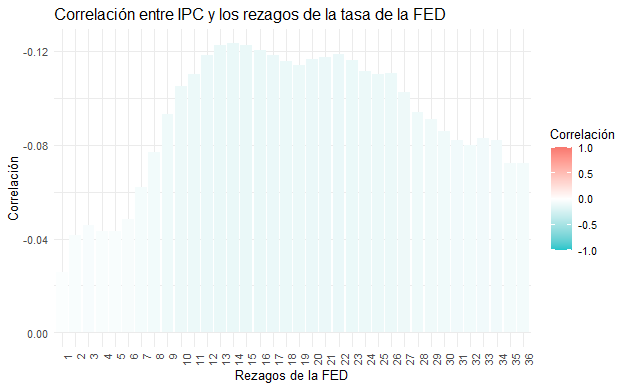

```r
# Gráfico de correlaciones

# Etiquetas del eje X
correlation_table_1$Lag <- as.numeric(gsub("FED_lag_", "", correlation_table_1$Lag))
correlation_table_1$Lag <- factor(correlation_table_1$Lag, levels = sort(unique(correlation_table_1$Lag)))

ggplot(correlation_table_1, aes(x = Lag, y = Correlation, fill = Correlation)) +
  geom_bar(stat = "identity") +
  scale_fill_gradient2(low = "#1ac5ca", high = "#f87970", mid = "#ffffff", midpoint = 0, name = "Correlación", limits = c(-1, 1)) +
  theme_minimal() +
  theme(axis.text.x = element_text(angle = 90, hjust = 1)) +
  labs(title = "Correlación entre IPC y los rezagos de la tasa de la FED",
       x = "Rezagos de la FED",
       y = "Correlación") +
  scale_y_reverse()
```

Al observar los valores de correlación notamos:

Aunque los resultados muestran que existe una relación entre los rezagos de la tasa de la FED y la inflación, la relación es débil y no parece ser inmediata ni fuerte.

## 3 Otros indicadores de inflación

Al no observar datos claramente relevantes, podría ser útil considerar otros factores para una comprensión más precisa del impacto de la política monetaria sobre la inflación. Incorporamos al análisis distintates variables del IPC, como son el IPC núcleo, que excluye precios estacionales y coyunturales y la expectativa de inflación según la [Universidad de Michigan](https://fred.stlouisfed.org/graph/?g=4PA). Veamos la correlación para cada una de las variables.

```r
# IPC Núcleo
getSymbols("CPILFESL", src = "FRED", from = first_date, to = Sys.Date())
```

```
[1] "CPILFESL"
```

```r
core_ipc_df <- data.frame(
  Date = index(CPILFESL),
  IPC_core = as.numeric(CPILFESL[, 1])
)

core_ipc_df$IPC_core_Monthly <- c(NA, diff(core_ipc_df$IPC_core))
core_ipc_df$IPC_core_Monthly <- as.numeric(core_ipc_df$IPC_core_Monthly)

#  Expectativas de inflación de la Universidad de Michigan
getSymbols("MICH", src = "FRED", from = first_date, to = Sys.Date())
```

```
[1] "MICH"
```

```r
expectations_df <- data.frame(
  Date = index(MICH),
  IPC_exp = as.numeric(MICH[, 1])
)

# Incorporación de variables
merged_df <- merge(merged_df, core_ipc_df, by = "Date", all.x = TRUE)
merged_df <- merge(merged_df, expectations_df, by = "Date", all.x = TRUE)
merged_df <- na.omit(merged_df)

# Correlación

# IPC_core
correlations_core_1 <- sapply(1:months, function(i) cor(merged_df$IPC_core_Monthly, merged_df[[paste("FED_lag", i, sep = "_")]], use = "complete.obs"))

# IPC_exp
correlations_exp_1 <- sapply(1:months, function(i) cor(merged_df$IPC_exp, merged_df[[paste("FED_lag", i, sep = "_")]], use = "complete.obs"))

# Tabla de correlaciones
correlation_table_2 <- data.frame(
  Lag = 1:months,
  IPC_Monthly = correlations_1,
  IPC_core = correlations_core_1,
  IPC_exp = correlations_exp_1
)

correlation_table_2
```

| Lag | IPC_Monthly | IPC_core | IPC_exp |
| --- | --- | --- | --- |
| 1 | -0.02580976 | -0.004084896 | -0.04719360 |
| 2 | -0.04151193 | -0.024916217 | -0.06760280 |
| 3 | -0.04586223 | -0.042468598 | -0.08477967 |
| 4 | -0.04303121 | -0.054414789 | -0.09864650 |
| 5 | -0.04325949 | -0.064314329 | -0.11019062 |
| 6 | -0.04834786 | -0.077299207 | -0.12292577 |
| 7 | -0.06206057 | -0.092937557 | -0.13646171 |
| 8 | -0.07689997 | -0.108222750 | -0.14774368 |
| 9 | -0.09311203 | -0.124140477 | -0.16056261 |
| 10 | -0.10502533 | -0.138571997 | -0.17599575 |

[output cut: 26 more lines]

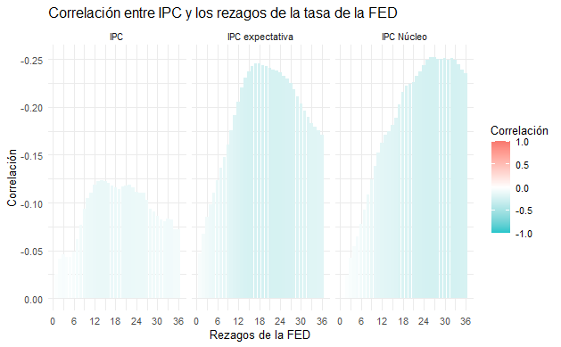

```r
# Tabla con las tres correlaciones
correlation_graph_2 <- data.frame(
  Lag = rep(1:months, 3),
  IPC = c(correlations_1, correlations_core_1, correlations_exp_1),
  Type = rep(c("IPC", "IPC Núcleo", "IPC expectativa"), each = months)
)

# Gráfico de correlaciones

# Etiquetas del eje X
correlation_graph_2$Lag <- as.factor(correlation_table_2$Lag)
correlation_graph_2$Lag <- as.numeric(as.character(correlation_graph_2$Lag)) # Lag a numérico

ggplot(correlation_graph_2, aes(x = Lag, y = IPC, fill = IPC)) +
  geom_bar(stat = "identity", position = "dodge") +
  scale_fill_gradient2(low = "#1ac5ca", high = "#f87970", mid = "#ffffff", midpoint = 0, name = "Correlación", limits = c(-1, 1)) +
  scale_y_reverse(limits = c(0, min(correlation_graph_2$IPC))) +  # Invertir el eje Y, empezando en 0
  scale_x_continuous(breaks = seq(0, max(correlation_graph_2$Lag, na.rm = TRUE), by = 6)) +  # Múltiplos de 6
  theme_minimal() +
  labs(title = "Correlación entre IPC y los rezagos de la tasa de la FED",
       x = "Rezagos de la FED",
       y = "Correlación") +
  facet_wrap(~Type, scales = "fixed")  # Mantener el mismo eje en todos los gráficos
```

La relación entre los rezagos y las distintas variantes de IPC es siempre negativa. Mientras la expectativa de IPC muestra valores algo más significativos en cuanto a la correlación, esto se hace más evidente en el IPC núcleo. Vemos como resultaría un modelo de regresión para predecir dicha variable.

```r
# Regresión
fed_lags <- paste("FED_lag", 1:months, sep = "_", collapse = " + ")
model <- lm(paste("IPC_core_Monthly ~", fed_lags), data = merged_df)
summary(model)
```

```
Call:
lm(formula = paste("IPC_core_Monthly ~", fed_lags), data = merged_df)

Residuals:
     Min       1Q   Median       3Q      Max
-1.32462 -0.17210 -0.06285  0.10601  1.60029

Coefficients:
             Estimate Std. Error t value Pr(>|t|)
(Intercept)  0.523992   0.030858  16.981  < 2e-16 ***
FED_lag_1    0.415597   0.139690   2.975  0.00313 **
FED_lag_2   -0.288767   0.249516  -1.157  0.24795
FED_lag_3   -0.203072   0.255745  -0.794  0.42772
FED_lag_4   -0.106376   0.255750  -0.416  0.67771
FED_lag_5    0.241805   0.256046   0.944  0.34564
FED_lag_6    0.131458   0.254150   0.517  0.60532
FED_lag_7   -0.185334   0.250186  -0.741  0.45933
FED_lag_8    0.078577   0.248121   0.317  0.75167
FED_lag_9   -0.097216   0.248430  -0.391  0.69580
FED_lag_10   0.125302   0.247660   0.506  0.61322
FED_lag_11  -0.153679   0.247853  -0.620  0.53564
FED_lag_12   0.098242   0.246773   0.398  0.69080
FED_lag_13  -0.282751   0.245652  -1.151  0.25052
FED_lag_14   0.209805   0.245930   0.853  0.39419
FED_lag_15  -0.155244   0.246208  -0.631  0.52876
FED_lag_16   0.442570   0.245782   1.801  0.07263 .
FED_lag_17  -0.062514   0.245877  -0.254  0.79946
FED_lag_18  -0.174322   0.246357  -0.708  0.47967
FED_lag_19  -0.223877   0.246390  -0.909  0.36418
FED_lag_20   0.055606   0.246447   0.226  0.82162
FED_lag_21   0.289566   0.245958   1.177  0.23989
FED_lag_22  -0.182746   0.245199  -0.745  0.45660
FED_lag_23   0.052430   0.244268   0.215  0.83017
FED_lag_24   0.086368   0.240915   0.358  0.72019
FED_lag_25  -0.117745   0.239340  -0.492  0.62306
FED_lag_26  -0.078767   0.239396  -0.329  0.74234
FED_lag_27   0.004395   0.238433   0.018  0.98530
FED_lag_28   0.123358   0.239657   0.515  0.60707
FED_lag_29   0.050763   0.241258   0.210  0.83347
FED_lag_30  -0.228038   0.241245  -0.945  0.34519
FED_lag_31   0.279115   0.241255   1.157  0.24810
FED_lag_32  -0.149856   0.241767  -0.620  0.53577
FED_lag_33  -0.019106   0.240972  -0.079  0.93685
FED_lag_34  -0.015742   0.240921  -0.065  0.94794
FED_lag_35   0.033411   0.236446   0.141  0.88771
FED_lag_36  -0.020510   0.134696  -0.152  0.87906
---
Signif. codes:  0 ‘***’ 0.001 ‘**’ 0.01 ‘*’ 0.05 ‘.’ 0.1 ‘ ’ 1

Residual standard error: 0.3433 on 346 degrees of freedom
Multiple R-squared:  0.1714,    Adjusted R-squared:  0.08523
F-statistic: 1.989 on 36 and 346 DF,  p-value: 0.0009479
```

## 4 Últimos años

```r
# Filtrar los datos según la fecha
start_date <- as.Date("2000-01-01")
filtered_df <- merged_df[merged_df$Date >= start_date, ]

# Calcular las correlaciones para los tres tipos de IPC (IPC, IPC Núcleo, IPC Expectativa)
correlations_2 <- sapply(1:months, function(lag) cor(filtered_df$IPC, filtered_df[[paste0("FED_lag_", lag)]]))
correlations_core_2 <- sapply(1:months, function(lag) cor(filtered_df$IPC_core, filtered_df[[paste0("FED_lag_", lag)]]))
correlations_exp_2 <- sapply(1:months, function(lag) cor(filtered_df$IPC_exp, filtered_df[[paste0("FED_lag_", lag)]]))

# Tabla de correlaciones
correlation_table_3 <- data.frame(
  Lag = 1:months,
  IPC_Monthly = correlations_2,
  IPC_core = correlations_core_2,
  IPC_exp = correlations_exp_2
)

correlation_table_3
```

| Lag | IPC_Monthly | IPC_core | IPC_exp |
| --- | --- | --- | --- |
| 1 | -0.07203707 | -0.05721104 | 0.053911254 |
| 2 | -0.09109686 | -0.07553471 | 0.029086295 |
| 3 | -0.11047330 | -0.09429716 | 0.008106616 |
| 4 | -0.13100266 | -0.11448237 | -0.008488249 |
| 5 | -0.15193217 | -0.13531600 | -0.021888232 |
| 6 | -0.17286048 | -0.15618846 | -0.036709047 |
| 7 | -0.19361826 | -0.17684541 | -0.052882459 |
| 8 | -0.21471748 | -0.19773392 | -0.066321469 |
| 9 | -0.23632432 | -0.21890139 | -0.082065727 |
| 10 | -0.25857600 | -0.24047078 | -0.101389321 |

[output cut: 26 more lines]

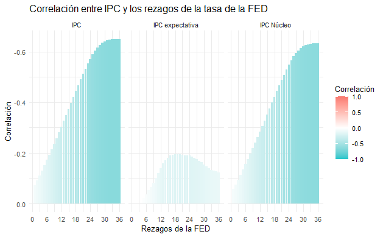

```r
# Tabla con las tres correlaciones
correlation_graph_3 <- data.frame(
  Lag = rep(1:months, 3),
  IPC = c(correlations_2, correlations_core_2, correlations_exp_2),
  Type = rep(c("IPC", "IPC Núcleo", "IPC expectativa"), each = months)
)

# Etiquetas del eje X
correlation_graph_3$Lag <- as.factor(correlation_table_3$Lag)
correlation_graph_3$Lag <- as.numeric(as.character(correlation_graph_3$Lag)) # Lag a numérico

ggplot(correlation_graph_3, aes(x = Lag, y = IPC, fill = IPC)) +
  geom_bar(stat = "identity", position = "dodge") +
  scale_fill_gradient2(low = "#1ac5ca", high = "#f87970", mid = "#ffffff", midpoint = 0, name = "Correlación", limits = c(-1, 1)) +
  scale_y_reverse(limits = c(0, min(correlation_graph_3$IPC))) +  # Invertir el eje Y, empezando en 0
  scale_x_continuous(breaks = seq(0, max(correlation_graph_3$Lag, na.rm = TRUE), by = 6)) +  # Múltiplos de 6
  theme_minimal() +
  labs(title = "Correlación entre IPC y los rezagos de la tasa de la FED",
       x = "Rezagos de la FED",
       y = "Correlación") +
  facet_wrap(~Type, scales = "fixed")  # Mantener el mismo eje en todos los gráficos
```

Tanto en el IPC como en el IPC Núcleo se observa un descalce inicial con la tasa de interés, con una correlación negativa que alcanza su punto más significativo más allá del mes 30. A partir de ese momento, ambas variables comienzan a alinearse gradualmente con la tasa de la FED. En contraste, la expectativa de IPC muestra una alineación mucho más temprana, lo que podría explicarse por la rapidez con la que los agentes económicos incorporan los cambios en la tasa de interés en sus expectativas de inflación.

## 5 Modelo

Para evaluar la relación entre la tasa de interés de la FED y la inflación núcleo (IPC Core), entrenamos un modelo de Random Forest con diferentes rezagos de la tasa como variables predictoras.

```r
# Normalizar los datos (excepto 'Date')
filtered_df_norm <- filtered_df %>%
  mutate(across(-Date, ~ as.numeric(scale(.))))

# Definir variables predictoras
fed_lags <- names(filtered_df_norm)[grepl("FED_lag_", names(filtered_df_norm))]

# Crear fórmula dinámica para el modelo
formula_rf <- as.formula(paste("IPC_core_Monthly ~", paste(fed_lags, collapse = " + ")))

# Dividir 'train' y 'test'
set.seed(54)  # Reproducibilidad
trainIndex <- createDataPartition(filtered_df_norm$IPC_core_Monthly, p = 0.8, list = FALSE)
trainData <- filtered_df_norm[trainIndex, ]
testData <- filtered_df_norm[-trainIndex, ]

# Entrenar Random Forest
model_rf <- randomForest(formula_rf, data = trainData, ntree = 500)

# Predicciones
predictions <- predict(model_rf, newdata = testData)

# Métricas: Error cuadrático medio & R^2
mse <- mean((predictions - testData$IPC_core_Monthly)^2)
rsq <- 1 - sum((predictions - testData$IPC_core_Monthly)^2) / sum((testData$IPC_core_Monthly - mean(testData$IPC_core_Monthly))^2)

print(paste("MSE: ", mse))
```

```
[1] "MSE:  0.565655268923077"
```

```r
print(paste("R-squared: ", rsq))
```

```
[1] "R-squared:  0.50070030666945"
```

```r
# Importancia de variables
importance(model_rf)
```

```
           IncNodePurity
FED_lag_1       9.608956
FED_lag_2      10.000694
FED_lag_3       6.966608
FED_lag_4       3.434717
FED_lag_5       2.475674
FED_lag_6       2.663142
FED_lag_7       3.542509
FED_lag_8       4.919112
FED_lag_9       3.416648
FED_lag_10      4.992623
FED_lag_11      8.733686
FED_lag_12     23.995550
FED_lag_13     12.850697
FED_lag_14      7.002214
FED_lag_15      4.074155
FED_lag_16      3.488377
FED_lag_17      3.299612
FED_lag_18      6.368548
FED_lag_19      3.179679
FED_lag_20      2.796081
FED_lag_21      3.639809
FED_lag_22      2.319423
FED_lag_23      3.087652
FED_lag_24      3.685630
FED_lag_25      3.087154
FED_lag_26      3.212093
FED_lag_27      3.390588
FED_lag_28      4.732204
FED_lag_29      2.982094
FED_lag_30      4.716446
FED_lag_31      5.757411
FED_lag_32      6.812357
FED_lag_33      7.082287
FED_lag_34     10.653068
FED_lag_35     16.532514
FED_lag_36     17.527283
```

El modelo de Random Forest sugiere que aproximadamente la mitad de la variabilidad en la inflación núcleo puede explicarse a partir de los rezagos de la tasa de la FED. Esto indica que la política monetaria tiene un impacto significativo, aunque no es el único factor en juego.

En cuanto a la importancia de los distintos rezagos, se observa que los efectos más relevantes se producen alrededor del año de retraso, lo que es consistente con la idea de que los cambios en la tasa de interés tardan en transmitirse a la inflación. Sin embargo, también aparecen rezagos de mayor plazo, sugiriendo que la política monetaria puede seguir teniendo impacto incluso varios años después de su implementación.

Estos resultados refuerzan la noción de que la relación entre tasas de interés e inflación no es inmediata y que existen efectos diferidos que deben considerarse al analizar la efectividad de las decisiones de política económica.

## 6 Hiperparámetros

Introducimos ciertos hiperparámetros para ajustar el modelo.

Buscamos determinar el mejor valor de mtry para optimizar el rendimiento del modelo a través de una evaluación del error fuera de la bolsa.

El error fuera de la bolsa (OOB) es una medida de desempeño en Random Forest, calculada utilizando los datos que no se emplean en la construcción de cada árbol. Estos datos, que se dejan fuera en cada iteración debido al muestreo con reemplazo, se utilizan luego para evaluar el modelo, proporcionando una estimación precisa sin necesidad de un conjunto de validación.

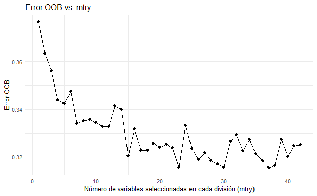

```r
set.seed(54)

# Definir hiperparámetros a probar
tuneGrid <- expand.grid(mtry = seq(2, ncol(trainData) - 1, by = 2))

# Guardar errores OOB para distintos valores de mtry
mtry_values <- 1:(ncol(trainData) - 1)
oob_errors <- numeric(length(mtry_values))

for (i in mtry_values) {
  rf_model <- randomForest(IPC_core_Monthly ~ ., data = trainData, mtry = i, ntree = 500)
  oob_errors[i] <- rf_model$mse[length(rf_model$mse)]  # Último valor de error OOB
}

# Graficar OOB error vs mtry
df <- data.frame(mtry = mtry_values, oob_error = oob_errors)
ggplot(df, aes(x = mtry, y = oob_error)) +
  geom_point(size = 2) +
  geom_line() +
  ggtitle("Error OOB vs. mtry") +
  xlab("Número de variables seleccionadas en cada división (mtry)") +
  ylab("Error OOB") +
  theme_minimal()
```

### 6.1 Validación cruzada

Realizamos una validación cruzada para encontrar el mejor valor de mtry y entrenar un modelo de Random Forest más robusto. El desempeño del modelo se evalúa mediante el error cuadrático medio (MSE) y el coeficiente de determinación (R-squared).

```r
# Encontrar el mejor mtry
rf_tuned <- train(IPC_core_Monthly ~ ., data = trainData,
                  method = "rf",
                  tuneGrid = tuneGrid,
                  trControl = trainControl(method = "cv", number = 5),  # 5-fold CV
                  ntree = 500)

# Entrenar el modelo con el mejor mtry
model_rf <- randomForest(IPC_core_Monthly ~ .,
                         data = trainData,
                         mtry = rf_tuned$bestTune$mtry,  # Mejor mtry
                         ntree = 500,
                         nodesize = 5)  # Puedes ajustar `nodesize`

# Realizar predicciones
predictions <- predict(model_rf, newdata = testData)

# Calcular MSE y R-squared usando IPC_core_Monthly como variable real
mse <- mean((predictions - testData$IPC_core_Monthly)^2)
rsq <- 1 - sum((predictions - testData$IPC_core_Monthly)^2) / sum((testData$IPC_core_Monthly - mean(testData$IPC_core_Monthly))^2)

# Imprimir los resultados
print(paste("MSE: ", mse))
```

```
[1] "MSE:  0.483790136539211"
```

```r
print(paste("R-squared: ", rsq))
```

```
[1] "R-squared:  0.572962049358684"
```

### 6.2 Otros hiperparámetros

**ntree (Número de árboles):** Controla la cantidad de árboles en el bosque. A mayor número de árboles, el modelo tiende a ser más robusto y preciso, pero a costa de un mayor tiempo de cómputo.

**nodesize (Tamaño del nodo):** Establece el número mínimo de observaciones requeridas en un nodo terminal. Valores más bajos permiten mayor flexibilidad en la división, lo que puede generar modelos más complejos y susceptibles al sobreajuste. Valores más altos hacen que los árboles sean más generales y menos propensos al sobreajuste, pero pueden ser demasiado simples.

```r
# Definir los valores de ntree y nodesize a probar
ntree_values <- c(100, 200, 500, 1000)
nodesize_values <- c(1, 5, 10, 20)

# Crear un data frame vacío para almacenar los resultados
results <- data.frame(mtry = integer(), ntree = integer(), nodesize = integer(), MSE = numeric(), Rsq = numeric())

# Loop sobre los valores de ntree y nodesize
for (ntree_value in ntree_values) {
  for (nodesize_value in nodesize_values) {

    # Definir el tuneGrid solo con mtry
    tuneGrid <- expand.grid(mtry = seq(2, ncol(trainData) - 1, by = 2))

    # Entrenar el modelo con el valor actual de ntree y nodesize
    rf_tuned <- train(IPC_core_Monthly ~ ., data = trainData,
                      method = "rf",
                      tuneGrid = tuneGrid,
                      trControl = trainControl(method = "cv", number = 5),  # 5-fold CV
                      ntree = ntree_value,
                      nodesize = nodesize_value)

    # Obtener el mejor mtry
    best_mtry <- rf_tuned$bestTune$mtry

    # Entrenar el modelo con los mejores valores de los tres hiperparámetros
    model_rf <- randomForest(IPC_core_Monthly ~ .,
                             data = trainData,
                             mtry = best_mtry,
                             ntree = ntree_value,
                             nodesize = nodesize_value)

    # Realizar predicciones
    predictions <- predict(model_rf, newdata = testData)

    # Calcular MSE y R-squared
    mse <- mean((predictions - testData$IPC_core_Monthly)^2)
    rsq <- 1 - sum((predictions - testData$IPC_core_Monthly)^2) / sum((testData$IPC_core_Monthly - mean(testData$IPC_core_Monthly))^2)

    # Guardar los resultados
    results <- rbind(results, data.frame(mtry = best_mtry, ntree = ntree_value, nodesize = nodesize_value, MSE = mse, Rsq = rsq))
  }
}

# Imprimir los resultados
print(results)
```

| mtry | ntree | nodesize | MSE | Rsq |
| --- | --- | --- | --- | --- |
| 10 | 100 | 1 | 0.4741491 | 0.5814721 |
| 34 | 100 | 5 | 0.4732079 | 0.5823029 |
| 26 | 100 | 10 | 0.5024771 | 0.5564672 |
| 42 | 100 | 20 | 0.4698669 | 0.5852520 |
| 40 | 200 | 1 | 0.4630365 | 0.5912812 |
| 34 | 200 | 5 | 0.4770861 | 0.5788796 |
| 40 | 200 | 10 | 0.4930146 | 0.5648197 |
| 32 | 200 | 20 | 0.4844078 | 0.5724169 |
| 34 | 500 | 1 | 0.4620490 | 0.5921528 |
| 14 | 500 | 5 | 0.4988656 | 0.5596551 |

[output cut: 6 more lines]

No se observan diferencias significativas en el rendimiento al variar los hiperparámetros mtry, ntree y nodesize, por lo que se puede concluir que un ajuste moderado es suficiente para obtener buenos resultados. Las variaciones en el MSE y R-squared son mínimas, lo que sugiere que no es necesario realizar cambios complejos en los hiperparámetros. Se puede optar por una configuración eficiente sin comprometer el rendimiento, priorizando el rendimiento general sobre la optimización extrema de los parámetros.

## 7 Impacto mundial

Incorporamos al análisis los ratio de conversión del dólar a monedas de otros países para ver cómo afecta la tasa de la FED en el mundo. Utilizamos las siguientes modenas:

1. [Euro](https://fred.stlouisfed.org/series/DEXUSEU), U.S. Dollars to One Euro
2. [Yuan](https://fred.stlouisfed.org/series/DEXCHUS), Chinese Yuan Renminbi to One U.S. Dollar
3. [Yen](https://fred.stlouisfed.org/series/DEXJPUS), Japanese Yen to One U.S. Dollar
4. [Real](https://fred.stlouisfed.org/series/DEXBZUS), Brazilian Reals to One U.S. Dollar

```r
# Obtener los datos de la tasa de cambio
start_currency_date <- as.Date("2000-01-01")

# Ratio Dólar vs Euro (Euro a Dólar)
getSymbols("DEXUSEU", src = "FRED", from = start_currency_date, to = Sys.Date())
```

```
[1] "DEXUSEU"
```

```r
dolar_euro_df <- data.frame(
  Date = index(DEXUSEU),
  EUR_USD = 1 / as.numeric(DEXUSEU[, 1])  # Invertir la tasa de cambio
)

# Ratio Dólar vs Yuan (Chinese Yuan Renminbi to One U.S. Dollar)
getSymbols("DEXCHUS", src = "FRED", from = start_currency_date, to = Sys.Date())
```

```
[1] "DEXCHUS"
```

```r
yuan_df <- data.frame(
  Date = index(DEXCHUS),
  USD_CNY = as.numeric(DEXCHUS[, 1])
)

# Ratio Dólar vs Yen (Japanese Yen to One U.S. Dollar)
getSymbols("DEXJPUS", src = "FRED", from = start_currency_date, to = Sys.Date())
```

```
[1] "DEXJPUS"
```

```r
yen_df <- data.frame(
  Date = index(DEXJPUS),
  USD_JPY = as.numeric(DEXJPUS[, 1])
)

# Ratio Dólar vs Real (Brazilian Reals to One U.S. Dollar)
getSymbols("DEXBZUS", src = "FRED", from = start_currency_date, to = Sys.Date())
```

```
[1] "DEXBZUS"
```

```r
real_df <- data.frame(
  Date = index(DEXBZUS),
  USD_BRL = as.numeric(DEXBZUS[, 1])
)
```

Creamos una función $get_monthly_avg$ que toma un data frame y lo agrega según su promedio mensual, para luego poder comparar estos valores con la tasa de interés mensual.

```r
get_monthly_avg <- function(df, currency_name) {
  # Columna 'Date' esté en formato Date
  df$Date <- as.Date(df$Date)

  # Columna con el mes y año
  df$YearMonth <- format(df$Date, "%Y-%m")

  # Agrupar por mes y agregar por promedio
  df_monthly_avg <- df %>%
    group_by(YearMonth) %>%
    summarise(across(where(is.numeric), mean, na.rm = TRUE))

  # Renombrar la columna correspondiente a la moneda
  df_monthly_avg <- df_monthly_avg %>%
    rename(!!currency_name := !!sym(currency_name), Date = YearMonth)

  return(df_monthly_avg)
}
```

Aplicamos la función y creamos el data frame necesario. Luego graficamos un mapa de calor para ver la correlación del comportamiento de cada moneda con la variación de la tasa de la FED.

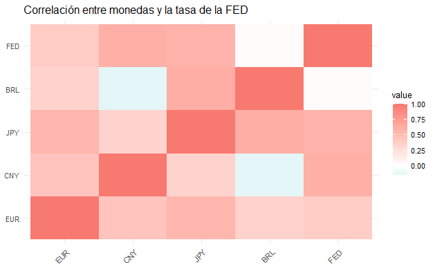

```r
# Promedio mensual
euro_df_monthly <- get_monthly_avg(dolar_euro_df, "EUR_USD")
yuan_df_monthly <- get_monthly_avg(yuan_df, "USD_CNY")
yen_df_monthly <- get_monthly_avg(yen_df, "USD_JPY")
real_df_monthly <- get_monthly_avg(real_df, "USD_BRL")

# Creación del Data Frame
currency_df <- merge(euro_df_monthly, yuan_df_monthly, by = "Date", all = TRUE)
currency_df <- merge(currency_df, yen_df_monthly, by = "Date", all = TRUE)
currency_df <- merge(currency_df, real_df_monthly, by = "Date", all = TRUE)

fed_df <- fed_df %>%
  mutate(Date = format(as.Date(Date), "%Y-%m"))

currency_df <- merge(currency_df, fed_df, by = "Date", all = TRUE)
currency_df <- na.omit(currency_df)

currency_numeric_df <- currency_df %>% select_if(is.numeric)
colnames(currency_numeric_df) <- gsub("USD|_", "", colnames(currency_numeric_df))

# Correlación
correlation_matrix <- cor(currency_numeric_df)

# Mapa de calor
correlation_melted <- melt(correlation_matrix)

ggplot(correlation_melted, aes(x = Var1, y = Var2, fill = value)) +
  geom_tile() +
  scale_fill_gradient2(low = "#1ac5ca", high = "#f87970", mid = "#ffffff", midpoint = 0) +
  theme_minimal() +
  theme(axis.text.x = element_text(angle = 45, hjust = 1)) +
  labs(title = "Correlación entre monedas y la tasa de la FED", x = NULL, y = NULL)
```

El mapa de calor nos deja ver que las monedas se devalúan frente al dólar en al subir la tasa de interés de la FED, sobre todo el Yuan y el Yen, de China y Japón respectivamente. Esto confirma el impacto mundial de esta variable. Vemos cómo se explica la variabilidad de la moneda china a través de la FED y sus rezagos.

```r
# Lags de la FED
merged_df_lags <- merged_df %>%
  select(Date, starts_with("FED_Lag"))  # Si las columnas de lags empiezan con "FED_Lag"
merged_df_lags <- merged_df_lags %>%
  mutate(Date = format(as.Date(Date), "%Y-%m"))

currency_df <- merge(currency_df, merged_df_lags, by = "Date", all = TRUE)

# Modelo
model_data <- currency_df %>%
  select(USD_CNY, starts_with("FED")) %>%
  na.omit()  # Eliminar filas con NA

set.seed(54)  # Semilla para reproducibilidad
train_index <- sample(1:nrow(model_data), 0.8 * nrow(model_data))
train_data <- model_data[train_index, ]
test_data <- model_data[-train_index, ]

lm_model <- lm(USD_CNY ~ ., data = train_data)
summary(lm_model)
```

```
Call:
lm(formula = USD_CNY ~ ., data = train_data)

Residuals:
     Min       1Q   Median       3Q      Max
-0.81601 -0.27993 -0.08172  0.32059  1.13175

Coefficients:
             Estimate Std. Error t value Pr(>|t|)
(Intercept)  6.282535   0.048888 128.508   <2e-16 ***
FED          0.559735   0.274402   2.040   0.0427 *
FED_lag_1   -0.407132   0.488543  -0.833   0.4056
FED_lag_2    0.050055   0.479274   0.104   0.9169
FED_lag_3   -0.001086   0.474117  -0.002   0.9982
FED_lag_4    0.000969   0.475813   0.002   0.9984
FED_lag_5    0.158886   0.491743   0.323   0.7469
FED_lag_6   -0.250619   0.515949  -0.486   0.6277
FED_lag_7    0.077232   0.488050   0.158   0.8744
FED_lag_8   -0.198775   0.503714  -0.395   0.6935
FED_lag_9    0.261012   0.501455   0.521   0.6033
FED_lag_10   0.009340   0.487153   0.019   0.9847
FED_lag_11   0.003534   0.475967   0.007   0.9941
FED_lag_12  -0.173996   0.490391  -0.355   0.7231
FED_lag_13   0.171722   0.506457   0.339   0.7349
FED_lag_14  -0.123081   0.477399  -0.258   0.7968
FED_lag_15  -0.009918   0.483821  -0.020   0.9837
FED_lag_16   0.041435   0.489350   0.085   0.9326
FED_lag_17   0.137063   0.481703   0.285   0.7763
FED_lag_18  -0.048408   0.478206  -0.101   0.9195
FED_lag_19   0.124501   0.453047   0.275   0.7837
FED_lag_20  -0.116699   0.468068  -0.249   0.8034
FED_lag_21  -0.023713   0.524152  -0.045   0.9640
FED_lag_22   0.000497   0.524320   0.001   0.9992
FED_lag_23  -0.204494   0.499225  -0.410   0.6825
FED_lag_24   0.279845   0.518770   0.539   0.5902
FED_lag_25  -0.140024   0.505956  -0.277   0.7823
FED_lag_26   0.011024   0.477666   0.023   0.9816
FED_lag_27   0.165830   0.466156   0.356   0.7224
FED_lag_28  -0.083100   0.479637  -0.173   0.8626
FED_lag_29  -0.048100   0.478866  -0.100   0.9201
FED_lag_30   0.119457   0.487840   0.245   0.8068
FED_lag_31  -0.305373   0.531285  -0.575   0.5661
FED_lag_32   0.073455   0.510680   0.144   0.8858
FED_lag_33   0.223569   0.539812   0.414   0.6792
FED_lag_34  -0.162725   0.493795  -0.330   0.7421
FED_lag_35  -0.051798   0.487587  -0.106   0.9155
FED_lag_36   0.310218   0.257539   1.205   0.2298
---
Signif. codes:  0 ‘***’ 0.001 ‘**’ 0.01 ‘*’ 0.05 ‘.’ 0.1 ‘ ’ 1

Residual standard error: 0.4484 on 202 degrees of freedom
Multiple R-squared:  0.7018,    Adjusted R-squared:  0.6472
F-statistic: 12.85 on 37 and 202 DF,  p-value: < 2.2e-16
```

```r
# Evaluación del modelo
predictions <- predict(lm_model, newdata = test_data)

mse <- mean((test_data$USD_CNY - predictions)^2)
r2 <- summary(lm_model)$r.squared

cat("MSE:", mse, "\nR²:", r2, "\n")
```

```
MSE: 0.228967
R²: 0.7018098
```

Según el R² del modelo se puede explicar cerca del 70% de la variabilidad en el tipo de cambio USD/CNY por la tasa de la FED. Sin embargo, a diferencia de la inflación, los rezagos no parecen tener significancia en el modelo, por lo que el impacto, en este caso, es inmediato.

## 8 Conclusiones

Realizamos un test de causalidad de Granger para entender si la tasa de interés de la FED afecta la inflación (y viceversa). Los resultados confirmaron que la tasa de la FED causa el IPC, lo que indica que las decisiones de política monetaria tienen un impacto significativo en la inflación.

Al analizar los rezagos de la tasa de la FED, encontramos una correlación negativa, sugiriendo que los aumentos en la tasa de interés tienden a estar asociados con una disminución en la inflación, aunque esta relación es débil y gradual. Es decir, el efecto de la política monetaria no es inmediato y persiste por varios meses. A pesar de esta relación débil, los resultados son consistentes con la idea de que las decisiones de la FED tienen un efecto a largo plazo.

Luego, incorporamos otras variables del IPC, como el IPC núcleo y las expectativas de inflación, para ver si podían ofrecer una visión más precisa. Al entrenar un modelo de regresión y un modelo de Random Forest para predecir el IPC núcleo, encontramos que, aunque el modelo explica alrededor del 50% de la variabilidad en el IPC núcleo, la relación con los rezagos de la tasa de la FED no es completa. Sin embargo, el modelo de Random Forest mostró que la política monetaria tiene un impacto significativo, pero que este efecto tarda en manifestarse.

Al ajustar los hiperparámetros del modelo, observamos que un ajuste moderado es suficiente para obtener buenos resultados, sin necesidad de una optimización extrema. Esto se validó con el error fuera de la bolsa (OOB) y el coeficiente de determinación (R²).

En resumen, mientras que la tasa de la FED tiene un impacto significativo en la inflación con efectos graduales y a largo plazo, su influencia sobre los tipos de cambio es inmediata, especialmente en monedas como el Yuan y el Yen.